# RTMB Base-Model Simulation and Refit Workflow

## 1 Purpose

This document records the parametric-bootstrap style workflow added around the saved RTMB base model. The current workflow treats the saved base-model fitted values as the data-generating truth, simulates new observations using the same observation variances and sample sizes, then refits the model to each simulated data set.

The generated data sets are conditional on the base model point estimate. They do not yet include parameter uncertainty from a fitted Hessian or posterior distribution.

## 2 Simulation Steps

The simulation script is:

```r
rtmb_file("R", "simulate_base_datasets.R")
```

```
[1] "/Users/jim/_mymods/pollock/rtmb_ebswp/R/simulate_base_datasets.R"
```

Run it with:

```bash
NSIM=30 SEED=123 Rscript R/simulate_base_datasets.R
```

For each simulated data set, the script:

1. Reads the saved base report from `analysis/output/base.rds`.
2. Uses the base fitted values as truth:
   - `pred_catch`
   - `eb_bts`
   - `eb_ats`
   - `pred_cpue`
   - `pred_avo`
   - `phat_fsh`, `phat_bts`, and `phat_ats`.
3. Simulates new observations:
   - catch from the catch log-scale penalty implied by `catBio`;
   - BTS from the full BTS covariance matrix;
   - ATS from log-scale biomass variances;
   - CPUE and AVO from their observation variances;
   - fishery, BTS, and ATS age compositions from multinomial draws.
4. Returns a full RTMB-style `data` list with observed fields replaced by simulated values.

## 3 Estimation-Ready Data

Each simulated object is designed to be a direct replacement for the model `data` list used by `rpm()`. The simulation script now validates each data set before saving.

```r
if (!file.exists(sim_file)) {
  cat("Simulation file not found:", sim_file, "\n")
} else {
  sims <- readRDS(sim_file)
  cat("Simulation file:", sim_file, "\n")
  cat("Number of simulations:", length(sims$simulations), "\n")
  cat("Validation passed:", all(sims$validation %||% FALSE), "\n")
  cat("Estimation ready:", isTRUE(sims$metadata$estimation_ready), "\n")
}
```

```
Simulation file: /Users/jim/_mymods/pollock/rtmb_ebswp/analysis/output/simulated/base_simulated_datasets.rds
Number of simulations: 30
Validation passed: TRUE
Estimation ready: TRUE
```

The validation checks that:

- all required observed fields are present;
- index and catch values are finite and positive;
- age-composition matrices have `nages` columns;
- sample sizes and year vectors align with observed matrices;
- composition rows sum to one in the modeled age ranges;
- simulated data dimensions align with the base fitted quantities.

## 4 Refit Workflow

The refit script is:

```r
rtmb_file("R", "fit_simulated_datasets.R")
```

```
[1] "/Users/jim/_mymods/pollock/rtmb_ebswp/R/fit_simulated_datasets.R"
```

Run it with:

```bash
MAXSIM=30 Rscript R/fit_simulated_datasets.R
```

To refit the same simulated data sets with the fishery selectivity option changed to the 2D AR1 form (`fishery_sel_form = 5`), run:

```bash
FISHERY_SEL_FORM=5 FISHERY_SEL_LABEL=2dar1 \
  OUTPUT_DIR=analysis/output/simulated/refits_2dar1 \
  MAXSIM=30 Rscript R/fit_simulated_datasets.R
```

To refit the same simulated data sets with the time-varying 3-parameter double-logistic fishery selectivity form (`fishery_sel_form = 2`), run:

```bash
FISHERY_SEL_FORM=2 FISHERY_SEL_LABEL=double_logistic \
  OUTPUT_DIR=analysis/output/simulated/refits_double_logistic \
  MAXSIM=30 Rscript R/fit_simulated_datasets.R
```

The script rebuilds the RTMB objective for each simulated data set, runs `nlminb()`, and writes:

- `simulated_refits.rds`
- `simulated_refit_diagnostics.csv`
- `simulated_refit_timeseries.csv`
- `simulated_refit_fishery_selectivity.csv`

```r
diagnostics <- read_scenario_csv(
  c(diagnostics_file, diagnostics_double_logistic_file, diagnostics_2dar1_file),
  c("Base-form refit", "Double-logistic refit", "2D AR1 refit")
)
if (!is.null(diagnostics)) {
  print(diagnostics)
} else {
  cat("No refit diagnostics yet. Run MAXSIM=30 Rscript R/fit_simulated_datasets.R\n")
}
```

```
   simulation convergence                  message objective max_gradient
1           1           0 relative convergence (4)  5796.048 2.083745e-03
2           2           0 relative convergence (4)  6012.376 2.324003e-03
3           3           0 relative convergence (4)  5642.337 2.584159e-03
4           4           0 relative convergence (4)  5684.016 1.117998e-03
5           5           0 relative convergence (4)  5771.775 1.108154e-03
6           6           0 relative convergence (4)  5695.408 2.696898e-03
7           7           0 relative convergence (4)  6093.656 1.595397e-03
8           8           0 relative convergence (4)  5766.707 2.488768e-03
9           9           0 relative convergence (4)  5684.201 1.462364e-03
10         10           0 relative convergence (4)  5802.353 6.528753e-04
11         11           0 relative convergence (4)  5711.939 6.668726e-03
12         12           0 relative convergence (4)  5639.244 1.456999e-03
13         13           0 relative convergence (4)  5723.931 3.578110e-03
14         14           0 relative convergence (4)  5754.533 1.266391e-03
```

[output cut: 167 more lines]

```r
if (!is.null(diagnostics)) {
  summary_diag <- aggregate(
    max_gradient ~ scenario + convergence,
    diagnostics,
    function(x) sprintf("%0.4g to %0.4g", min(x, na.rm = TRUE), max(x, na.rm = TRUE))
  )
  names(summary_diag)[names(summary_diag) == "max_gradient"] <- "max_gradient_range"
  summary_diag$n <- as.integer(ave(
    diagnostics$simulation,
    diagnostics$scenario,
    diagnostics$convergence,
    FUN = length
  )[match(
    paste(summary_diag$scenario, summary_diag$convergence),
    paste(diagnostics$scenario, diagnostics$convergence)
  )])
  print(summary_diag)
}
```

```
               scenario convergence    max_gradient_range  n
1          2D AR1 refit           0 0.0003397 to 0.003131 30
2       Base-form refit           0 0.0006529 to 0.007499 30
3 Double-logistic refit           0        11.69 to 11.69  1
4 Double-logistic refit           1        1.088 to 8.388 29
```

## 5 Results

The comparisons below use the original base-model run as the data-generating truth. For each year, the shaded bands summarize the distribution of refitted estimates across simulated data sets.

### 5.1 SSB

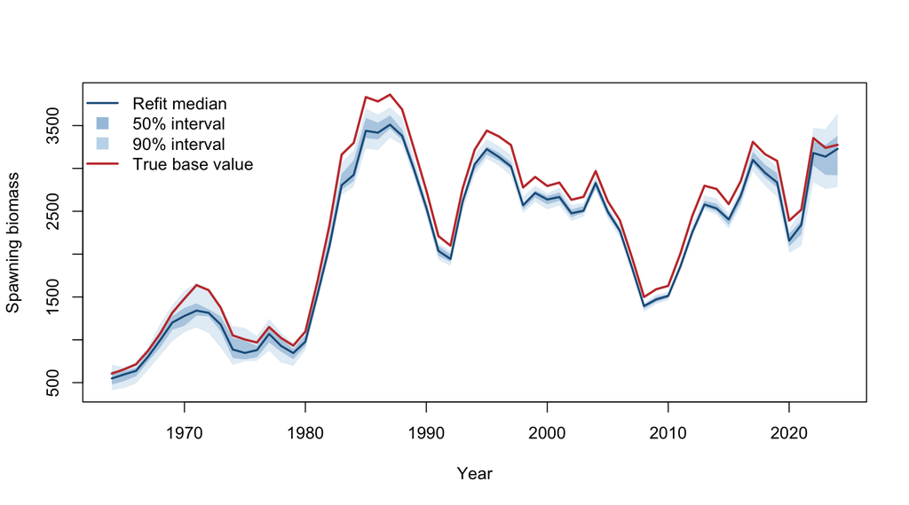

```r
if (file.exists(timeseries_file)) {
  refit_series <- read.csv(timeseries_file)
  plot_truth_distribution(refit_series, true_series, "SSB", "Spawning biomass")
} else {
  plot.new()
  text(0.5, 0.5, "Run MAXSIM=30 Rscript R/fit_simulated_datasets.R to create SSB refit output.")
}
```

### 5.2 Recruitment

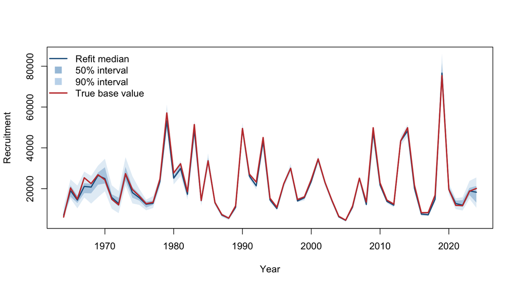

```r
if (file.exists(timeseries_file)) {
  refit_series <- read.csv(timeseries_file)
  plot_truth_distribution(refit_series, true_series, "recruitment", "Recruitment")
} else {
  plot.new()
  text(0.5, 0.5, "Run MAXSIM=30 Rscript R/fit_simulated_datasets.R to create recruitment refit output.")
}
```

### 5.3 Base Form, Double Logistic, and 2D AR1 Comparison

These panels compare estimates from refitting the same 30 simulated data sets with the base fishery selectivity form, the time-varying 3-parameter double-logistic form, and the 2D AR1 fishery selectivity form. The red line is the original base-model value used as the data-generating truth.

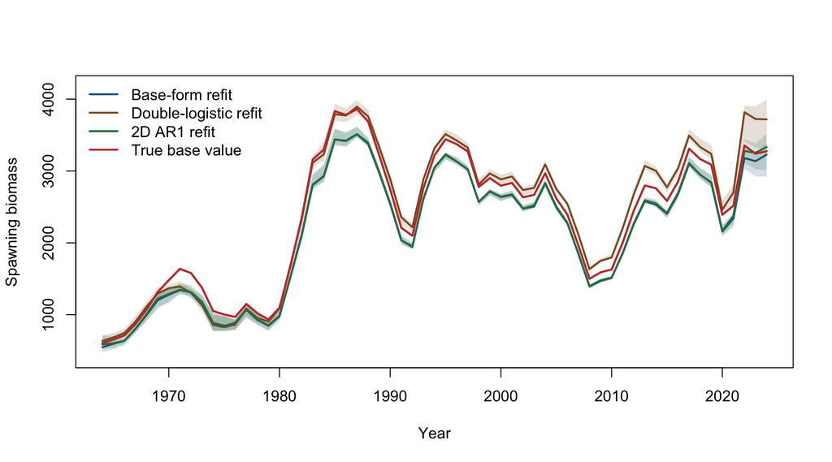

```r
scenario_series <- read_scenario_csv(
  c(timeseries_file, timeseries_double_logistic_file, timeseries_2dar1_file),
  c("Base-form refit", "Double-logistic refit", "2D AR1 refit")
)
if (!is.null(scenario_series)) {
  plot_scenario_distribution(scenario_series, true_series, "SSB", "Spawning biomass")
} else {
  plot.new()
  text(0.5, 0.5, "Run both simulated refit commands to create the comparison output.")
}
```

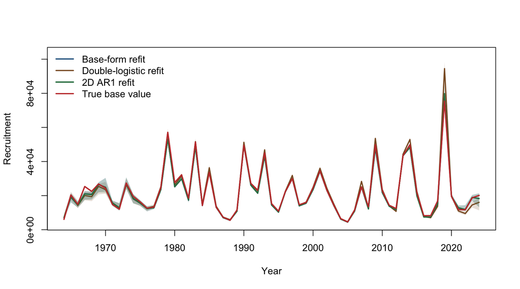

```r
if (!is.null(scenario_series)) {
  plot_scenario_distribution(scenario_series, true_series, "recruitment", "Recruitment")
} else {
  plot.new()
  text(0.5, 0.5, "Run both simulated refit commands to create the comparison output.")
}
```

### 5.4 Fishery Selectivity, Ages 3-8

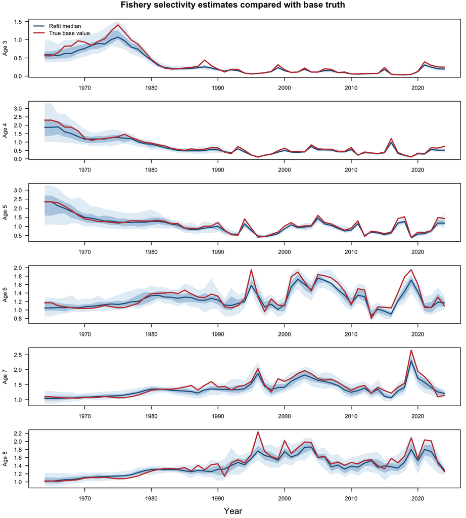

```r
if (file.exists(selectivity_file)) {
  sel_refit <- read.csv(selectivity_file)
  ages <- 3:8
  op <- par(mfrow = c(length(ages), 1), mar = c(2.2, 4.2, 1.3, 0.8), oma = c(2.2, 0, 1.5, 0), las = 1)
  for (a in ages) {
    d <- sel_refit[sel_refit$age == a, , drop = FALSE]
    t <- true_selectivity[true_selectivity$age == a, , drop = FALSE]
    years <- sort(unique(d$year))
    mat <- sapply(years, function(y) d$value[d$year == y])
    q <- apply(mat, 2, quantile, probs = c(0.05, 0.25, 0.5, 0.75, 0.95), na.rm = TRUE)
    truth_y <- t$true[match(years, t$year)]
    yrange <- range(c(q, truth_y), finite = TRUE)
    plot(years, q[3, ], type = "n", ylim = yrange, xlab = "", ylab = paste("Age", a))
    polygon(c(years, rev(years)), c(q[1, ], rev(q[5, ])), border = NA, col = adjustcolor("#8db9dd", 0.25))
    polygon(c(years, rev(years)), c(q[2, ], rev(q[4, ])), border = NA, col = adjustcolor("#4f8fc0", 0.35))
    lines(years, q[3, ], lwd = 2, col = "#1f5f8b")
    lines(years, truth_y, lwd = 2.2, col = "#c43c39")
    if (a == ages[1]) {
      legend(
        "topleft",
        legend = c("Refit median", "True base value"),
        col = c("#1f5f8b", "#c43c39"),
        lty = 1,
        lwd = c(2, 2.2),
        bty = "n"
      )
    }
  }
  mtext("Year", side = 1, outer = TRUE, line = 0.8)
  mtext("Fishery selectivity estimates compared with base truth", side = 3, outer = TRUE, line = 0.2, font = 2)
  par(op)
} else {
  plot.new()
  text(0.5, 0.5, "Run MAXSIM=30 Rscript R/fit_simulated_datasets.R to create selectivity refit output.")
}
```

### 5.5 Fishery Selectivity, Base Form vs Double Logistic vs 2D AR1

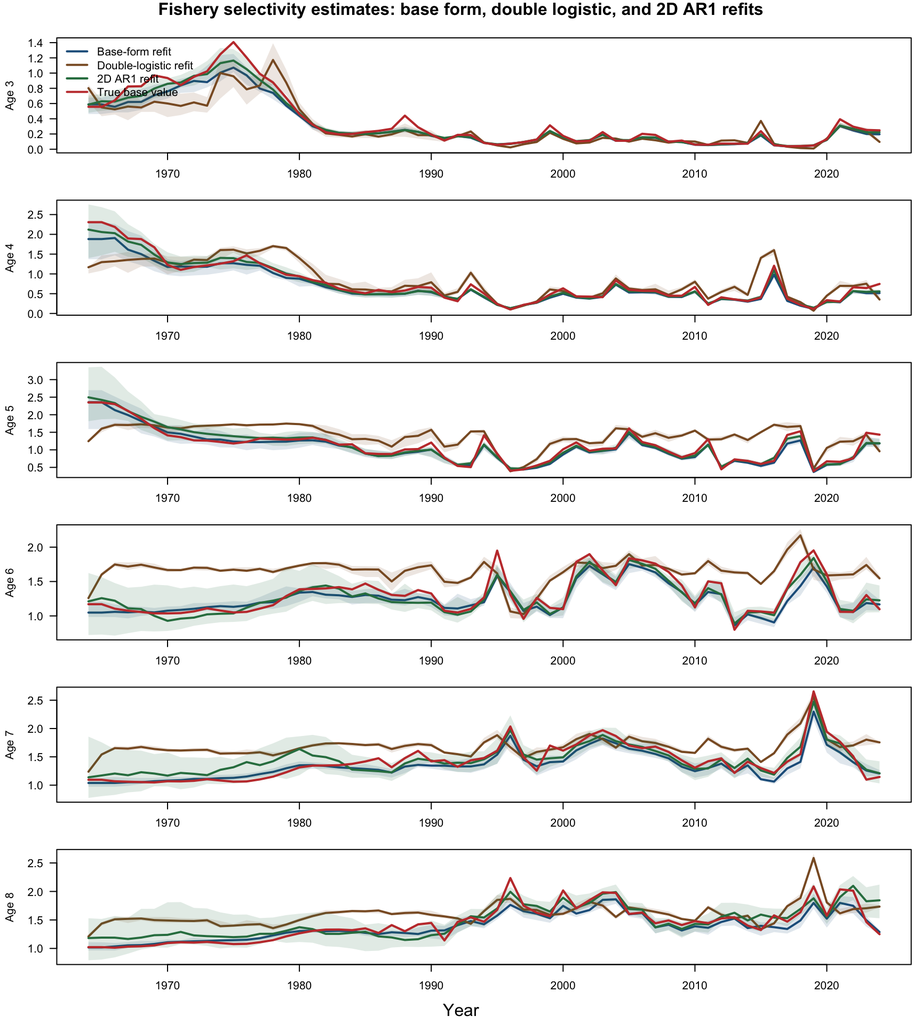

```r
scenario_sel <- read_scenario_csv(
  c(selectivity_file, selectivity_double_logistic_file, selectivity_2dar1_file),
  c("Base-form refit", "Double-logistic refit", "2D AR1 refit")
)
if (!is.null(scenario_sel)) {
  ages <- 3:8
  cols <- c(
    "Base-form refit" = "#1f5f8b",
    "Double-logistic refit" = "#8a5a2b",
    "2D AR1 refit" = "#2f7d4f"
  )
  op <- par(mfrow = c(length(ages), 1), mar = c(2.2, 4.2, 1.3, 0.8), oma = c(2.2, 0, 1.5, 0), las = 1)
  for (a in ages) {
    d <- scenario_sel[scenario_sel$age == a, , drop = FALSE]
    t <- true_selectivity[true_selectivity$age == a, , drop = FALSE]
    q <- scenario_quantiles(d)
    years <- sort(unique(q$year))
    truth_y <- t$true[match(years, t$year)]
    yrange <- range(c(q$q25, q$q75, truth_y), finite = TRUE)
    plot(years, truth_y, type = "n", ylim = yrange, xlab = "", ylab = paste("Age", a))
    for (sc in names(cols)) {
      qs <- q[q$scenario == sc, , drop = FALSE]
      if (nrow(qs) == 0) next
      polygon(c(qs$year, rev(qs$year)), c(qs$q25, rev(qs$q75)), border = NA, col = adjustcolor(cols[[sc]], 0.14))
      lines(qs$year, qs$q50, lwd = 2, col = cols[[sc]])
    }
    lines(years, truth_y, lwd = 2.1, col = "#c43c39")
    if (a == ages[1]) {
      legend(
        "topleft",
        legend = c(names(cols), "True base value"),
        col = c(cols, "#c43c39"),
        lty = 1,
        lwd = c(2, 2, 2.1),
        bty = "n"
      )
    }
  }
  mtext("Year", side = 1, outer = TRUE, line = 0.8)
  mtext("Fishery selectivity estimates: base form, double logistic, and 2D AR1 refits", side = 3, outer = TRUE, line = 0.2, font = 2)
  par(op)
} else {
  plot.new()
  text(0.5, 0.5, "Run both simulated refit commands to create selectivity comparison output.")
}
```

## 6 Existing Illustration Figures

These figures illustrate the simulated observations before refitting.

```r
bts_plot <- rtmb_file("analysis/output/figures/simulated_bts_index_30.png")
fishery_plot <- rtmb_file("analysis/output/figures/simulated_fishery_age_props_by_year_30.png")
cat("BTS plot:", bts_plot, "\n")
```

```
BTS plot: /Users/jim/_mymods/pollock/rtmb_ebswp/analysis/output/figures/simulated_bts_index_30.png
```

```r
cat("Fishery age-composition plot:", fishery_plot, "\n")
```

```
Fishery age-composition plot: /Users/jim/_mymods/pollock/rtmb_ebswp/analysis/output/figures/simulated_fishery_age_props_by_year_30.png
```

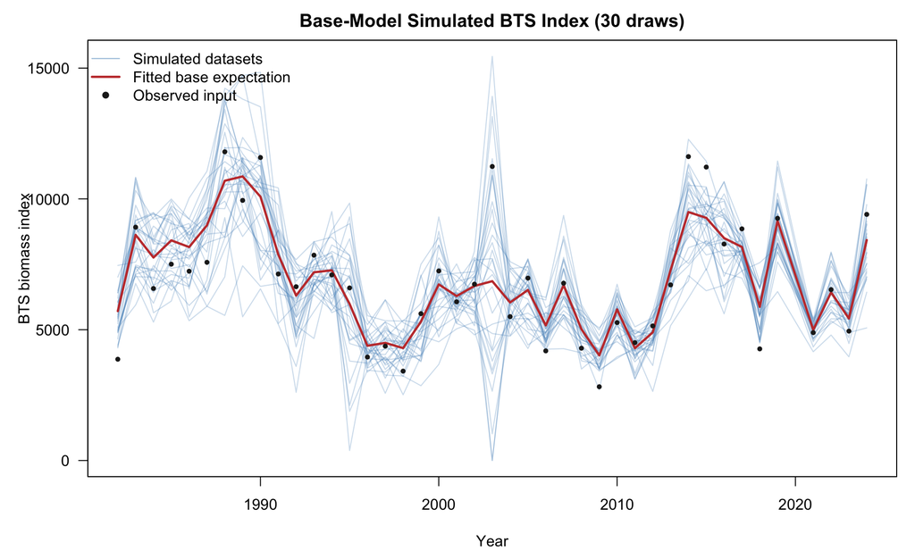

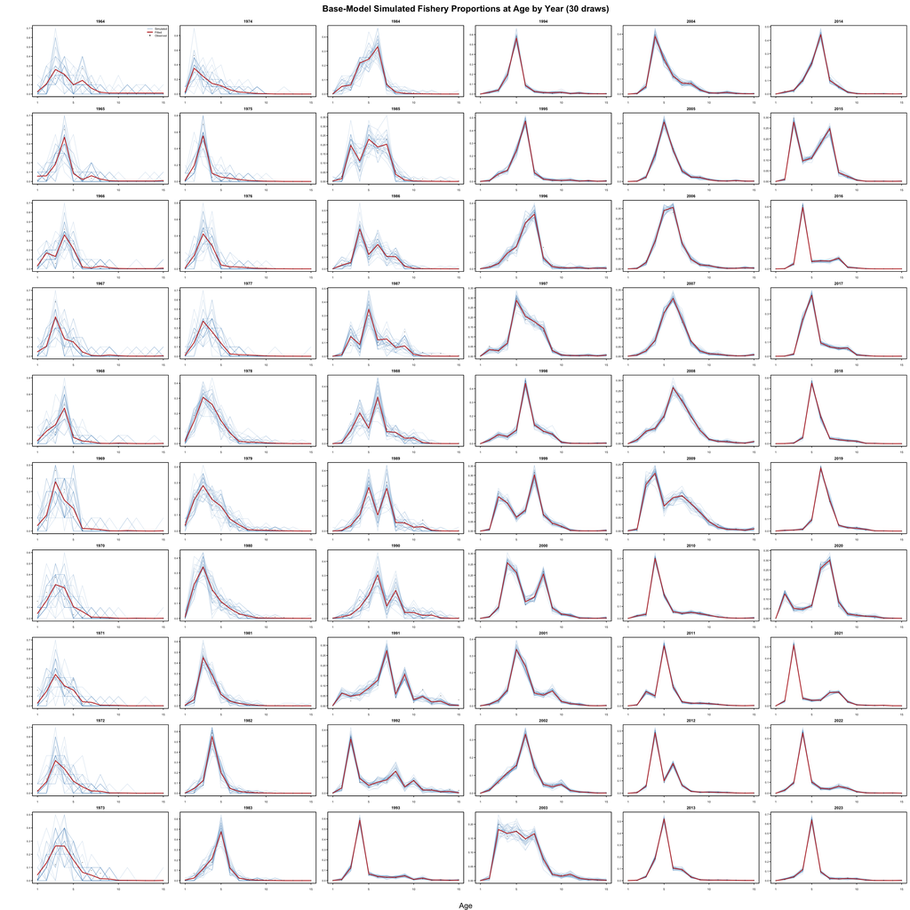